# HW4 (Data analysis in astronomy)

# Building a simple machine learning algorithm

# Have fun!!!

### Your name: Cheng-An, Hsieh

### Deadline 12/22 11:59 pm

### Introduction: in this homework, we are going to use PCA, logistic regression, SVM, decision tree and random forest to build models to predict the numbers shown on the images.

```python
import numpy as np
import astropy.io.fits as pf
import matplotlib.pyplot as plt
import seaborn as sns; sns.set()
import scipy.stats as ss
from sklearn.decomposition import PCA
```

```python
### 1. We will use
### training data set https://www.dropbox.com/s/43coge30onvdkl2/Training.fits?dl=0
### test data set https://www.dropbox.com/s/2ex0l7ncwgpbq75/Test.fits?dl=0
```

```python
training = pf.open('HW4/Training.fits')
### training[0].data -> images
### training[1].data -> number labels
```

```python
X_train = training[0].data
y_train = training[1].data
test = pf.open('HW4/Test.fits')

X_test = test[0].data
y_test = test[1].data
```

### Simple illustration

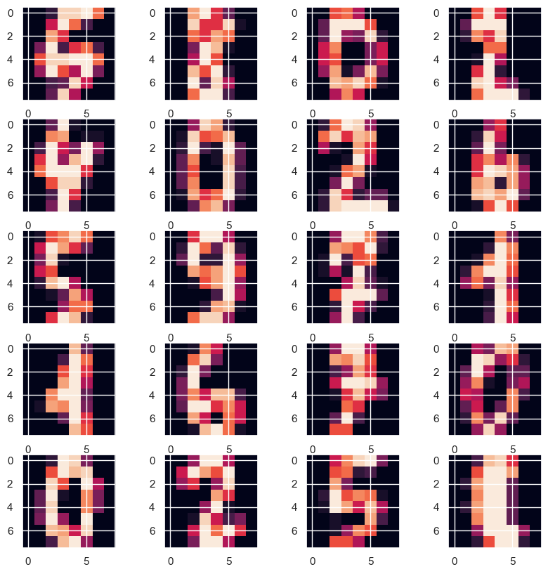

```python
plt.figure(figsize=(10,10))
for i in range(0,20):
    plt.subplot(5,4,i+1)
    plt.imshow(X_train[i*50].reshape(8,8))
```

### Two weeks ago, we learned that we can use PCA to obtain the coefficients

```python
pca = PCA(30)
pca.fit(X_train)
coeff = pca.transform(X_train)
print('Total variance explained by the eigenimages:%0.2f' % np.sum(pca.explained_variance_ratio_))
```

```
Total variance explained by the eigenimages:0.96
```

### from the distribution of the coeff [0,1], we noticed that different numbers have different coefficients. This means that we can use the coefficients to distinguish the numbers.

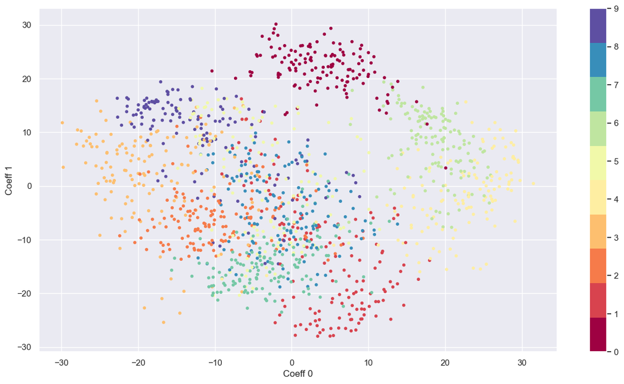

```python
plt.figure(figsize=(15,8))
plt.scatter(coeff[:,0],coeff[:,1],c=y_train,cmap=plt.cm.get_cmap('Spectral', 10),s=10)
plt.colorbar()
plt.xlabel('Coeff 0')
plt.ylabel('Coeff 1')
```

### Now, Let us start with using logistic regression (when providing multiclass information, the logisticsRegression will automatically change to softmax regression)to do the classification.

### Here we first use the first two coefficients

```python
import sklearn.linear_model as sl
import sklearn.metrics as sm
import sklearn.svm as ss
```

```python
lr = sl.LogisticRegression(max_iter=1000000)
lr.fit(coeff[:,:2],y_train)
number_pred = lr.predict(coeff[:,:2])
```

### We are going to use "accuracy_score" as our metric this time (Check the accruracy score document for its definitation)

```python
print('Accuracy_score')
print(sm.accuracy_score(y_train,number_pred))
#print(sm.accuracy_score(y_test,test_pred))
```

```
Accuracy_score
0.6013363028953229
```

### The color code shows the prediction results

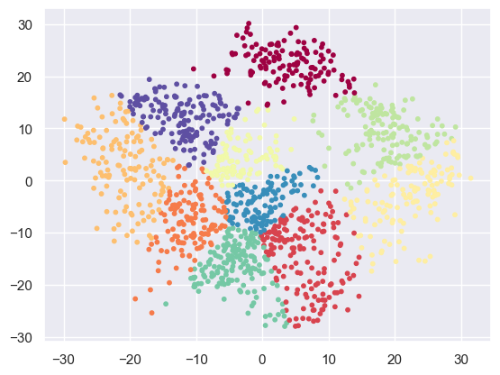

```python
plt.scatter(coeff[:,0],coeff[:,1],c=number_pred,cmap=plt.cm.get_cmap('Spectral', 10),s=10)
```

### To do:

### 1. Write a code to do "for loop" to increase the number of coefficients used in the training and

### plot x-axis (Number of coefficients) and y-axis (accuracy score)

### [15 points]

```
[0.36080178173719374, 0.6013363028953229, 0.7112100965107646, 0.8092056421677802, 0.8596881959910914, 0.8730512249443207, 0.9049740163325909, 0.9153674832962138, 0.9428359317000743, 0.9510022271714922, 0.9561989606533037, 0.96362286562732, 0.96362286562732, 0.9732739420935412, 0.9784706755753526, 0.…
```

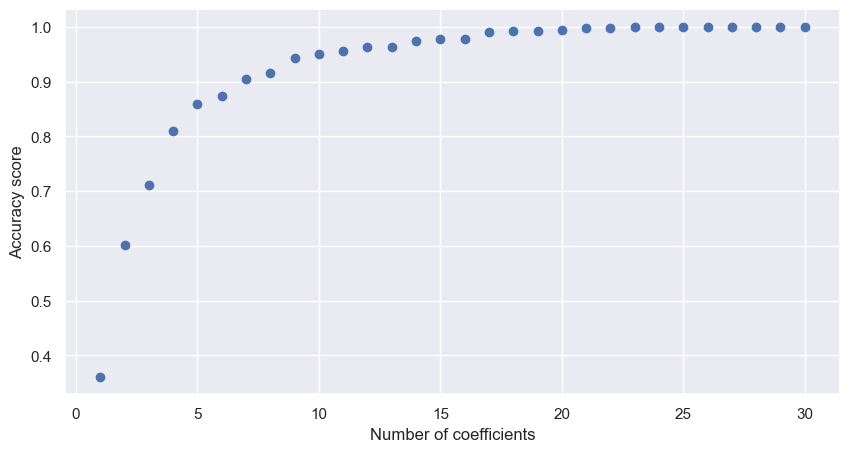

```python
### 1. Write a code to do "for loop" to increase the number of coefficients used in the training and

#Apply the method to test data set, produce the same plot x-axis (Number of coefficients) and y-axis (accuracy score)

coeff_t = pca.transform(X_test)
accuracy_t = []
accuracy = []

for i in range(1,31):

    lr = sl.LogisticRegression(max_iter=1000000)
    lr.fit(coeff[:,:i],y_train)
    number_pred = lr.predict(coeff[:,:i])
    number_pred_t = lr.predict(coeff_t[:,:i])
    accuracy.append(sm.accuracy_score(y_train,number_pred))
    accuracy_t.append(sm.accuracy_score(y_test,number_pred_t))

print(accuracy)
### plot x-axis (Number of coefficients) and y-axis (accuracy score)
plt.figure(figsize=(10,5))
plt.scatter(range(1,31),accuracy)
plt.xlabel('Number of coefficients')
plt.ylabel('Accuracy score')
plt.show()
```

### 2. Apply the method to test data set, produce the same plot x-axis (Number of coefficients) and y-axis (accuracy score),